# CUMTD Data Collection

### Overview

This site serves to be a small data analysis experiment on the CUMTD (Champaign-Urbana Mass Transit District) bus system. Originally started out as a project to accurately predict the times that the buses would arrive (since Google Maps doesn’t), this site has evolved to show more statistics on more specific parts of the bus system and its API.

### Aims

1. Visualize the delays as shown by the getDeparturesByStop function and the realtime bus arrival times.
2. Visualize the delays by certain bus routes
3. Integrate Google Traffic data to predict the delays of buses
4. Display bus arrivals by location (campus boundaries, greater Champaign-Urbana area)
5. Display bus delays by location
6. Help users choose a bus by visually displaying bus delays, arrival times, and locations on a map

### Below data was last updated December 09, 2018 at 01:08:05

### Plotting delay vs. time of day

We can figure out if there is a difference in the delay of buses by time of the day. Maybe traffic at certain times of the day create more delays for the buses?

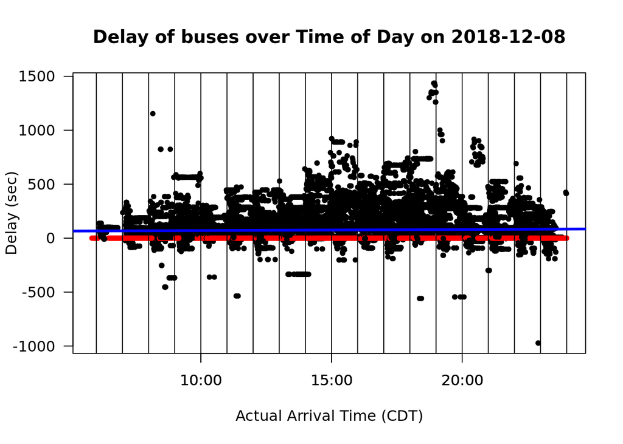

```r
arrTimeDates <- sapply(all_times, function(time) {paste(date, time)})
arrPOSIX <- as.POSIXct(arrTimeDates, format="%Y-%m-%d %H:%M:%S", origin="1960-01-01")
cols <- rep(1, length(all_delays))
cols[all_delays == 0] <- 2
plot(all_delays ~ arrPOSIX, xlab="Actual Arrival Time (CDT)", ylab="Delay (sec)", main=paste("Delay of buses over Time of Day on", date), las=1, pch=20, col=cols)
axis.POSIXct(1, x=arrPOSIX)

# add vertical lines to show beginning of hour, in case variation was higher at the beginnning of the hour
lines <- as.POSIXct(sapply(seq(0, 24, 1), function (time) {paste(date, time)}), format="%Y-%m-%d %H")
abline(v=lines)

# linear model
fit <- lm(all_delays ~ arrPOSIX)
abline(fit, col="BLUE", lwd=3)
```

```r
# technically shouldn't be correlated? need more data to prove (could be sample size causing less variability)
summary(fit)
```

```
##
## Call:
## lm(formula = all_delays ~ arrPOSIX)
##
## Residuals:
##      Min       1Q   Median       3Q      Max
## -1054.91   -77.48   -69.45    27.55  1356.94
##
## Coefficients:
##               Estimate Std. Error t value Pr(>|t|)
## (Intercept) -4.121e+05  6.657e+04  -6.190 6.08e-10 ***
## arrPOSIX     2.669e-04  4.311e-05   6.191 6.04e-10 ***
## ---
## Signif. codes:  0 '***' 0.001 '**' 0.01 '*' 0.05 '.' 0.1 ' ' 1
##
## Residual standard error: 137.2 on 33621 degrees of freedom
## Multiple R-squared:  0.001139,   Adjusted R-squared:  0.001109
## F-statistic: 38.33 on 1 and 33621 DF,  p-value: 6.04e-10
```

fitting to the linear model wasn’t completely necessary, but we can see if this confirms our belief that there isn’t a time of day that is significantly more/less delayed compared to other times of day.

### Plotting all of the bus delays

Plotting all of the bus delays might be nice to see if there is a general trend in the delay of the buses.
Some summary statistics on these buses:
$$\mu_{delays} = 75.84$$
$$\sigma_{delays} = 137.24$$
$$n = 33623$$

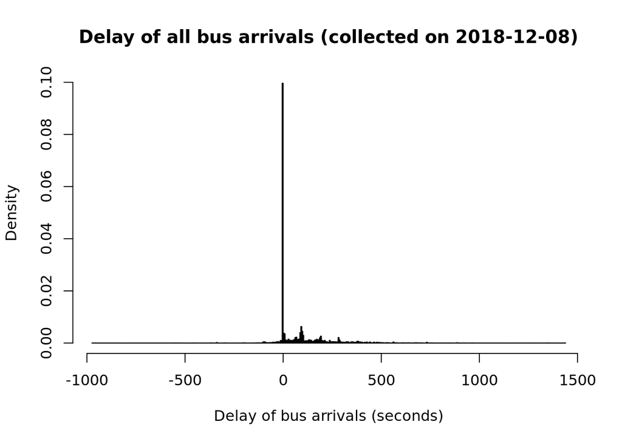

```r
delays_hist <- hist(all_delays, freq=FALSE, breaks=500, main=paste0("Delay of all bus arrivals (collected on ", date, ")"), xlab="Delay of bus arrivals (seconds)")
```

Since the number of 0’s (buses that arrived exactly on time- $estimated - scheduled = 0$) is so high, here is a zoomed in version of the same graph. The red bar is the bar containing all 0 values (buses that arrived exactly on time). There may be a preference towards showing a “0” value as opposed to other values, as shown in the histogram, but a definitive answer is unknown.

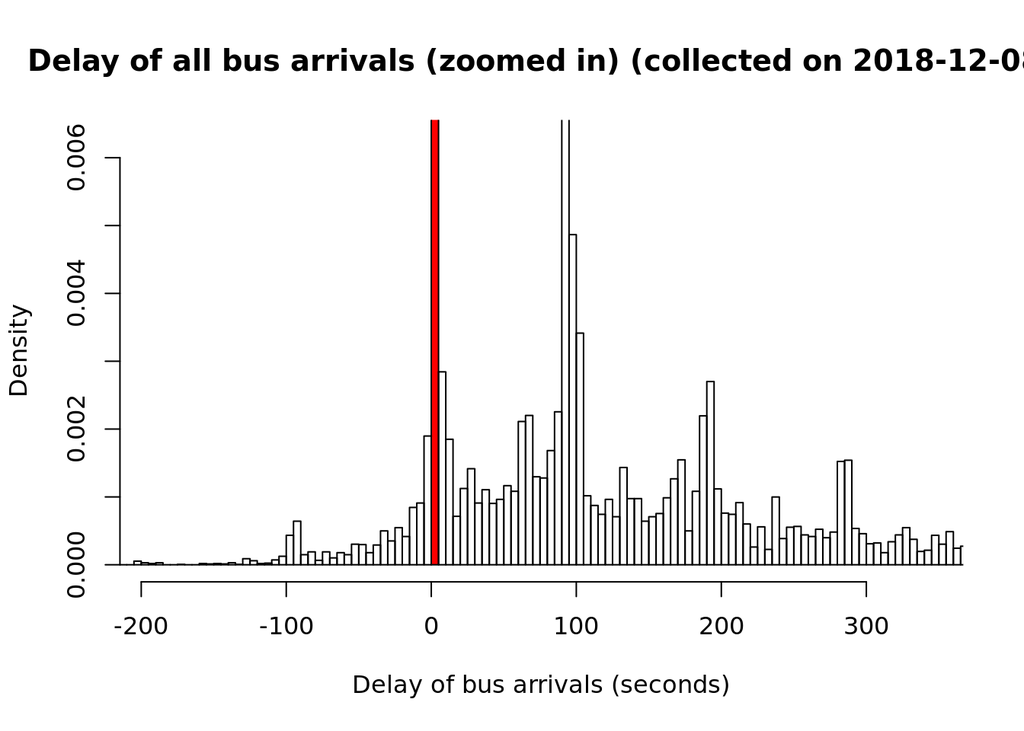

```r
# 95% of all values within 1.96 SDs of mean
xlim <- c(-1.96, 1.96) * sd(all_delays) + mean(all_delays)
# find second highest peak and make that the highest
ylim <- c(0, sort(delays_hist$density, decreasing=TRUE)[2])
cols <- rep(NULL, length(delays_hist$breaks))
cols[delays_hist$breaks==0] <- "red"
hist(all_delays,
     freq=FALSE,
     col=cols,
     right=FALSE,
     breaks=500,
     main=paste0("Delay of all bus arrivals (zoomed in) (collected on ", date, ")"),
     xlab="Delay of bus arrivals (seconds)",
     xlim=xlim,
     ylim=ylim)
```

### Plotting by bus route

There are a lot of bus routes, so maybe that is a confounder? Maybe some bus routes have higher rates of being late?

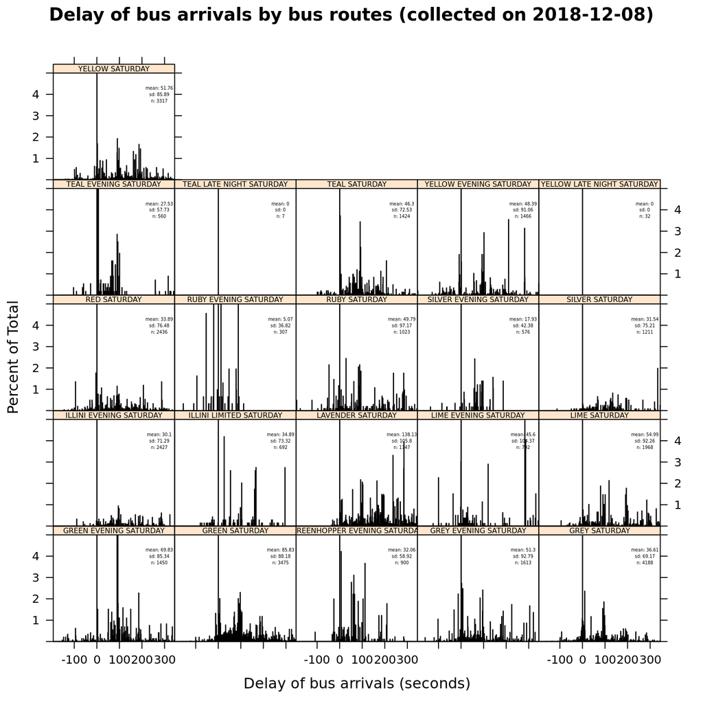

```r
data <- all_delays
confint95 <- c(-1.96, 1.96) * sd(data, na.rm=TRUE) + mean(data, na.rm=TRUE)
filter <- data < confint95[2] & data > confint95[1]
sorted_routes <- order(unique(all_routes[filter]))
y <- data[filter]
x <- all_routes[filter]
breaks <- seq(confint95[1], confint95[2], length.out=500)
histogram(~y | x,
          xlab="Delay of bus arrivals (seconds)",
          xlim=c(confint95[1],confint95[2]),
          ylim=c(0,5),
          breaks=breaks,
          main=paste0("Delay of bus arrivals by bus routes (collected on ", date, ")"),
          par.strip.text=list(cex=0.5),
          layout=c(5, ceiling(length(sorted_routes) / 5)),
          panel=function(x,...) {
              panel.histogram(x,...)
              panel.text(confint95[2]*0.8,4,
                  labels=paste0(
                      'mean: ', round(mean(x), 2), '\nsd: ', round(sd(x), 2), '\nn: ', length(x)),
                             cex=0.3)
          })
```